Álgebra Linear com Python

# Transformações Lineares

#### Em Matemática, uma transformação linear é um tipo particular de função entre dois espaços vetoriais que preserva as operações de adição vetorial e multiplicação por escalar. Uma transformação linear também pode ser chamada de aplicação linear ou mapa linear.

### Definição:

Se **T: V → W** é uma função de um espaço vetorial **V** em um outro espaço vetorial **W**, então **T** é chamada uma **transformação linear** de **V** em **W** se, para quaisquer vetor **u** e **v** em **V** e qualquer escalar **c** valem

- $a) T(u + v) = T(u) + T(v)$
- $b) T(cv) = cT(v)$

No caso especial em que **V = W**, a transformação linear é chamada um **operador linear** de **V**.

### Importação das Bibliotecas

```python
# importando a biblioteca numpy do python
import numpy
# importando a biblioteca matplotlib do python
import matplotlib.pyplot as plt
%matplotlib inline
```

```python
# importando a biblioteca 'plot_helper'
from plot_helper import *
```

- [Baixa o modulo plot_helper](https://github.com/Alyssonmach/Algebra-Linear-com-Python/blob/master/Conte%C3%BAdo%20J%20-%20Transforma%C3%A7%C3%B5es%20Lineares/plot_helper.py);

### Vetor Representado em Diferentes Pontos no Plano Cartesiano

Vamos agora começar a ver como podemos representar computacionalmente, no Python, vetores em um plano cartesiano.

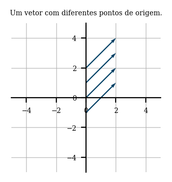

```python
# definindo um vetor qualquer
vetor = [(2,2)]
# pontos de origem do vetor acima
origens = [(0,-1), (0,1), (0,0), (0,2)]
# plota os gráficos do vetor, com seu respectivo módulo, direção, sentido e origem
plot_vector(vetor, origens)
# título do gráfico
plt.title("Um vetor com diferentes pontos de origem.");
```

### Soma de Vetores

Vamos agora realizar a soma entre dois vetores, dado que teremos um vetor resultante dessa operação.

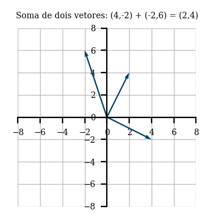

```python
# soma de vetores

# primeiro vetor
vetorA = numpy.array((4,-2))
# segundo vetor
vetorB = numpy.array((-2,6))

# uma lista de vetores = vetorA, vetorB e a soma vetorA + vetorB
vetores = [vetorA, vetorB, vetorA + vetorB]

# plota na tela o grafico dos vetores definidos
plot_vector(vetores)
# título do gráfico
plt.title("Soma de dois vetores: (4,-2) + (-2,6) = (2,4)");
```

### Subtração de Vetores

Vamos agora realizar a subtração entre dois vetores, dado que teremos um vetor resultante dessa operação.

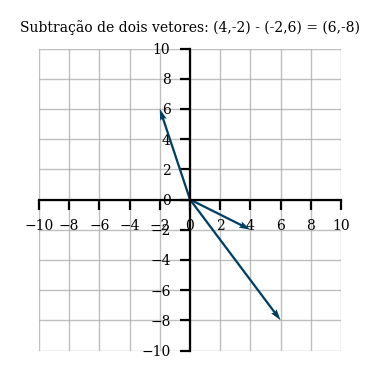

```python
# subtração de vetores

# primeiro vetor
vetorA = numpy.array((4,-2))
# segundo vetor
vetorB = numpy.array((-2,6))

# uma lista de vetores = vetorA, vetorB e a subtração vetorA - vetorB
vetores = [vetorA, vetorB, vetorA - vetorB]

# plota na tela o grafico dos vetores definidos
plot_vector(vetores)
# título do gráfico
plt.title("Subtração de dois vetores: (4,-2) - (-2,6) = (6,-8)");
```

### Multiplicação de um Vetor por um Escalar

Vamos agora realizar a multiplicação de um vetor por um escalar, dado que teremos um vetor resultante dessa operação.

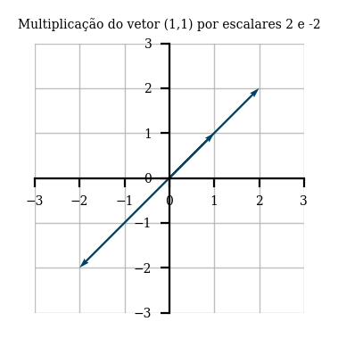

```python
# multiplicação de um vetor por um escalar

# criando um vetor c
vetorC = numpy.array((1,1))
# definindo uma lista de vetores, em que o vetorC é multiplicado por escalares
vetores = [vetorC, 2 * vetorC, -2 * vetorC]
# plota o gráfico dos dois vetores na tela
plot_vector(vetores)
# título do gráfico
plt.title("Multiplicação do vetor (1,1) por escalares 2 e -2");
```

### Base Canônica de um Vetor

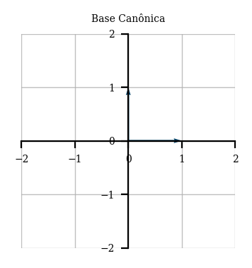

```python
# bases de um vetor

# definindo a componente i da base
i = numpy.array((1,0))
# definindo a componente j da base
j = numpy.array((0,1))

#definindo a liste de vetores
vetores = [i, j]

# plota o gráfico dos vetores definidos
plot_vector(vetores)
# título do gráfico
plt.title("Base Canônica");
```

Vamos mostrar que através da base canônica podemos representar qualquer vetor possível.

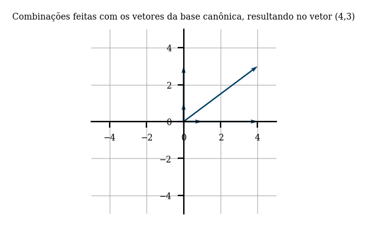

```python
# definindo uma lista de vetores
vetores = [i, j, (4 * i), (3 * j), (4 * i + 3 * j)]

# plota o gráfico dos vetores definidos
plot_vector(vetores)

# título do gráfico
plt.title("Combinações feitas com os vetores da base canônica, resultando no vetor (4,3)");
```

### Conjunto de Todas as Combinações Lineares Possíveis Entre Dois Vetores

```python
# importa a função da biblioteca Python: randint
from numpy.random import randint

# conjunto de todas as combinações lineares possíveis entre dois vetores
vetores = [] # lista vazia

# definindo a componente i da base
i = numpy.array((1,0))
# definindo a componente j da base
j = numpy.array((0,1))

# estrutura de repetição for, 1000 vezes, para o conteúdo abaixo
# nesse caso imprime 1000 vetores possíveis, resultado da combinação linear de outros dois vetores,
# no intervalo de (0,0) até (-10,10)

for _ in range(1000):
    # escolhe um número aleatório entre -10 e 10
    m = randint(-10,10)
    # escolhe um número aleatório entre -10 e 10
    n = randint(-10,10)
    # acrescenta a lista o vetor combinado com a base
    vetores.append(m * i + n * j)

# a lista incialmente vazia, agora armazena 1000 vetores na mémoria da máquina

# plota o gráfico da lista de vetores definidas
plot_vector(vetores)
# título do gráfico definido
plt.title("1000 vetores aleatórios criados a partir da base canônica");
```

[figure not shown]

### O mesmo pode ser feito a nível de combinação linear de dois vetores:

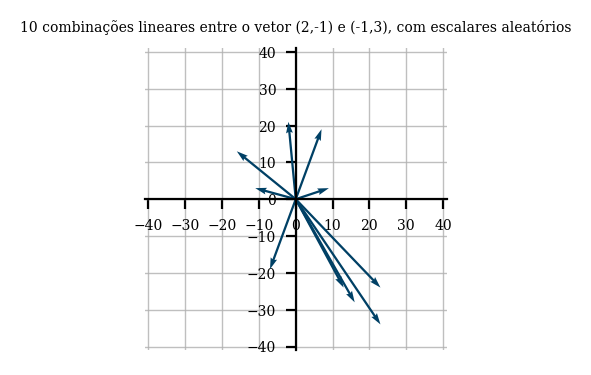

```python
# primeiro vetor
vetorA = numpy.array((2,-1))
# segundo vetor
vetorB = numpy.array((-1,3))

# lista vazia
vetores = []

#estrutura de repetição for que gera 10 vetores a partir de combinações aleatórias dos vetores a e b,
# com escalares entre -10 e 10
for _ in range(10):
    # escolhe um número aleatório entre -10 e 10
    escalar1 = randint(-10,10)
    # escolhe um número aleatório entre -10 e 10
    escalar2 = randint(-10,10)
    # acrescenta a lista o vetor combinado com a base
    vetores.append(escalar1 * vetorA + escalar2 * vetorB)

# a lista incialmente vazia, agora armazena 10 vetores na mémoria da máquina

# plota o gráfico da lista de vetores definidas
plot_vector(vetores)

# título do gráfico definido
plt.title("10 combinações lineares entre o vetor (2,-1) e (-1,3), com escalares aleatórios");
```

Podemos ter um vetor colinear, em que tendo 3 ou mais pontos, podemos traçar uma reta sobre ele

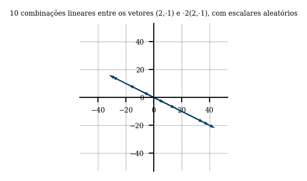

```python
# primeiro vetor
vetorA = numpy.array((2,-1))
# segundo vetor: A * -2, para se colinear
vetorD = numpy.array((-4,2))

vetores = [] # lista vazia

# estrutura de repetição for que gera 10 vetores aleatórios,com multiplicação por escalares entre (-10,10)
for _ in range(10):
    # escolhe um número aleatório entre -10 e 10
    escalar1 = randint(-10,10)
    # escolhe um número aleatório entre -10 e 10
    escalar2 = randint(-10,10)
    # adiciona a lista um vetor combinado da base
    vetores.append(escalar1 * vetorA + escalar2 * vetorD)

# a lista incialmente vazia, agora armazena 10 vetores na mémoria da máq

# plota o gráfico da lista de vetores definidos
plot_vector(vetores)

# título do gráfico
plt.title("10 combinações lineares entre os vetores (2,-1) e -2(2,-1), com escalares aleatórios");
```

### Transformações Lineares

Vamos usar uma matriz de transformação linear $$\begin{bmatrix} -2 & 1 \\ 1 & -3 \\ \end{bmatrix}$$ a partir da base canônica.

```python
# vamos fazer uma transformação linear
# temos a base usual do plano cartesiano x * (1,0) + y * (0,1)

# definimos uma matriz de transformação linear
baseA = numpy.array([(-2,1),(1,-3)])

# agora temos uma nova base fruto da transformação linear
plot_linear_transformation(baseA)
# x * (-2,1) + y * (1,-3)
```

[figure not shown]

### Aplicando uma Transformação Linear em um Vetor

Vamos usar uma matriz de transformação linear

$\begin{bmatrix} 1 & 2 \\ 2 & 1 \\ \end{bmatrix}$

a partir da base canônica. Vamos usar o vetor (1,2).

```python
# vamos fazer uma transformação linear (exemplo 1)
# temos a base usual do plano cartesiano x * (1,0) + y * (0,1)

# definimos uma matriz de transformação linear
baseM = numpy.array([(1,2),(2,1)])

# definimos um vetor
vetorX = numpy.array((1,2))

# definimos o vetor em duas situações: na base canônica e após a mudança de base
vetores = [vetorX, baseM.dot(vetorX)] # lista de vetores
# o segundo vetor da lista trata da multiplicação do vetorX pela nova matriz

# plotar o gráfico da lista de vetores
plot_vector(vetores)

# título do gráfico
plt.title("Aplicando uma Transformação Linear em um Vetor")
```

[figure not shown]

Observe que o vetor foi dilatado. Vamos usar um outro vetor para ver se a dilatação fica mais clara de se analisar.

```python
# vamos fazer uma transformação linear (exemplo 2)
# temos a base usual do plano cartesiano x * (1,0) + y * (0,1)

# definimos uma matriz
baseM = numpy.array([(1,2),(2,1)])
# definimos um vetor
vetorX = numpy.array((1,1))

# definimos o vetor em duas situações: na base canônica e após a mudança de base

# lista de vetores
vetores = [vetorX, baseM.dot(vetorX)]
 # plotar o gráfico da lista de vetores
plot_vector(vetores)

# título do gráfico
plt.title("Aplicando uma Transformação Linear em um Vetor")
```

[figure not shown]

#### Rotação

Vamos definir uma matriz de transformação linear responsável por rotacionar os vetores, mudando os seus sentidos.

Vamos usar uma matriz de transformação linear

$\begin{bmatrix} 0 & -1 \\ 1 & 0 \\ \end{bmatrix}$

a partir da base canônica.

```python
# definindo uma matriz de tranformação linear que rotaciona vetores
rotacao = numpy.array([[0,-1], [1,0]])
```

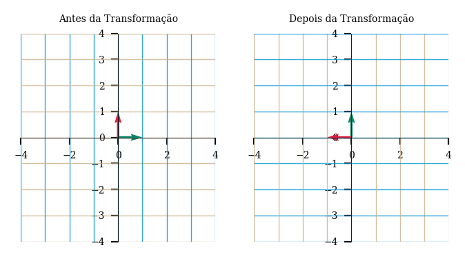

```python
# plotando o gráfico da transformação linear de rotação
plot_linear_transformation(rotacao)
```

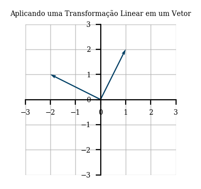

```python
# definimos um vetor
vetorX = numpy.array((1,2))

# definimos o vetor em duas situações: na base canônica e após sofrer a rotação

# lista de vetores
vetores = [vetorX, rotacao.dot(vetorX)]
# aplicando a rotação no vetorX

# plotar o gráfico da lista de vetores
plot_vector(vetores)

# título do gráfico
plt.title("Aplicando uma Transformação Linear em um Vetor")
```

### Mudança de escala

Podemos também usar uma transformação linear responsável por contrair um eixo e expandir outro, por exemplo.

Vamos usar uma matriz de transformação linear

$\begin{bmatrix} 2 & 0 \\ 0 & \frac{1}{2} \\ \end{bmatrix}$

a partir da base canônica.

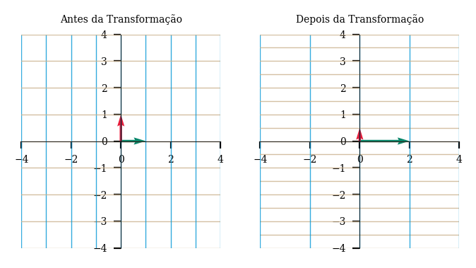

```python
# matriz de transformação que dobra o eixo x e diminui pela metade o eixo y
escala = numpy.array([[2,0], [0,0.5]])

# plotando o gráfico da nova base após a transformação linear
plot_linear_transformation(escala)
```

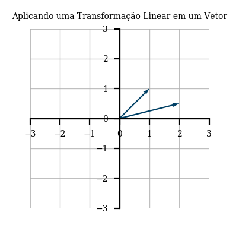

```python
# definimos um vetor
vetorX = numpy.array((1,1))

# definimos o vetor em duas situações: na base canônica e após a mudança de escala

# lista de vetores
vetores = [vetorX, escala.dot(vetorX)]
# mundando a escala do vetor

# plotar o gráfico da lista de vetores
plot_vector(vetores)

# título do gráfico
plt.title("Aplicando uma Transformação Linear em um Vetor")
```

### Aplicando Transformações Lineares Consecutivas

```python
base = numpy.array([[0,1],[-1,0]]) # definindo uma matriz de transformação para a base canônica

# a ordem de transformação é da direita para a esquerda
plot_linear_transformations(rotacao, base)
# plota os gráficos das duas transformações lineares na base de forma consecutiva
```

[figure not shown]

### Matriz Inversa

Acima foi usado uma matriz de trasformação que, após a base ter sido transformada pela matriz de rotação, ela a trasnformou novamente para a base canônica. Vamos usar a ideia de matriz inversa para fazer o meso processo.

Vamos usar uma matriz de transformação linear

$\begin{bmatrix} 1 & 2 \\ 2 & 1 \\ \end{bmatrix}$

a partir da base canônica.

```python
# importando a função da biblioteca numpy, do conjunto de funções linalg: inv
from numpy.linalg import inv
```

[figure not shown]

```python
baseM = numpy.array([(1,2),(2,1)]) # definimos uma matriz de transformação linear

M_inversa = inv(baseM) # define uma matriz inversa

# a ordem de transformação é da direita para a esquerda

# plota os gráficos das duas transformações lineares na base de forma consecutiva
plot_linear_transformations(baseM, M_inversa)
```

### Funções definidas por L. Barba e T. Wang para uma apresentação no evento SciPy 2019:

##### plot_vector, plot_linear_transformation e plot_linear_transformations¶

### Alguma Dúvida? Entre em Contato Comigo:

- Me envie um e-mail;